# Grafos

Pedro Correa

# Motivação

Ideal para modelar fatos do mundo real em que os relacionamentos possuem maior importância ou aparecem em grande quantidade, podendo até representar cenários dinâmicos.

# Árvore Geradora Mínima (MST - Minimum Spanning Tree)

É uma árvore que mora dentro do grafo, sendo que esta árvore deverá atingir todos os vértices da árvore. Essa árvore deverá conter o caminho que possui o menor peso da árvore. Diferente do modo de busca de largura da árvore, o foco é no peso das arestas, algo que não é utilizado na busca da largura.

Mas a MST tem algumas propriedades que devem ser prestadas atenção para saber se um grafo pode ser MST:

- O problema possui solução apenas se o grafo for **conexo**.
- Deverá conectar todos os vértices do grafo
- Não possui nenhum ciclo.
- Grafo não-direcionado
- Grafo ponderado

*Obs*: se todas as arestas tiverem o mesmo custo então toda árvore geradora será MST.

Bom, mas como podemos encontrá-la?

Podemos fazer por força bruta, assim testaremos todas as combinações possíveis e escolhemos a que der a menor soma. Mas acabamos encontrando problemas pois a implementação deste modo é difícil e muito custosa, pois o grafo pode ter *n* árvores geradores dentro de si.

## Algoritmos Gulosos (Greedy Algorithms)

**Algoritmos Gulosos**, que são algoritmos conhecidos por fazerem a melhor escolha no momento. O nome **guloso** é por causa que o algoritmo ele vai *engolindo* e adicionando os resultados, e no final, terá o resultante requerido. Essa estratégia não oferece a garantia de encontrar uma solução globalmente perfeitas para o problema. Mas com ela conseguimos provar uma MST.

Em seguida temos um exemplo de um lógica genérica para se encontrar a MST.

```c
void GenericoMST() {
    S = {};
    while(S não constitui uma árvore geradora mínima) {
        (u, v) = seleciona(A);
        if (aresta (u, v) é segura para)
            S = S + {(u, v)};
    }
    return S ;
}
```

Antes de cada iteração, S é um subconjunto de uma MST. A cada aresta que verificamos, adicionamos a S a aresta (u,v) que não viola a variante. Essa aresta é chamada de *aresta segura*.

Dentro do *while*, S tem que fazer parte do subconjunto prórpio da MST T, e quando existir uma aresta (u,v) que pertence a T e que não pertence a S e é considerado uma *aresta segura*, ele é adicionado ao conjunto de S.

## Corte | Aresta segura

Um corte é quando dividimos em parte o grafo, transformando o grafo em duas partes (V, S-V).

- `Um corte (V′, V−V′) de um grafo não direcionado G = (V, A) é uma partição de V.`

Neste corte há algumas arestas que o cruzam e estas arestas ligam um nó com outro nó,

- `Uma aresta (u, v) ∈ A cruza o corte (V′, V−V′) se um de seus vértices pertence a V′ e o outro vértice pertence a V−V′.`

assim, uma dessas arestas será parte da MST,

- `Um corte respeita um conjunto S de arestas se não existirem arestas em S que o cruzem.`

e como a MST necessita da aresta de menor peso, escolhemos a aresta que cruza esse corte para fazer parte da MST, essa aresta de valor mais baixo é chamada de **aresta leve**

- `Uma aresta cruzando o corte que tenha custo mínimo sobre todas as arestas cruzando o corte é uma aresta leve.`

Fazemos isso até conectarmos todos os nós do grafo.

## Algoritmo de Prim

Este algoritmo pode ser derivado do algoritmo anterior e a operação é muito semelhante ao algoritmo de Dijkstra para localizar o caminho mais curto em um grafo.

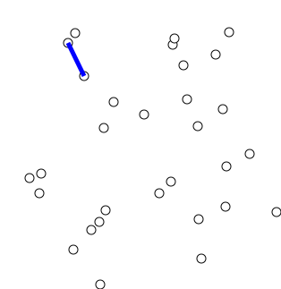

Exemplo do algoritmo de Prim

Neste algoritmo, o MST é gerada em um ponto escolhido arbitrariamente e a partir desde ponto, começamos adicionar as arestas que possuem o valor mínimo que ligam para algum ponto que não esteja conectada a subárvore, ou seja, verifica todas as *arestas seguras* a partir dos pontos que estejam no MST. Assim, quando é finalizado, as arestas encontradas formam uma MST.

## Algoritmo de Kruskal

Neste algoritmo não começamos por um ponto no grafo, criamos uma *floresta* com as arestas, então, a primeira coisa que é realizada é ordenar todos as arestas pelo peso. Após isso, selecionamos as arestas de peso menor e que sejam consideradas *segura*.

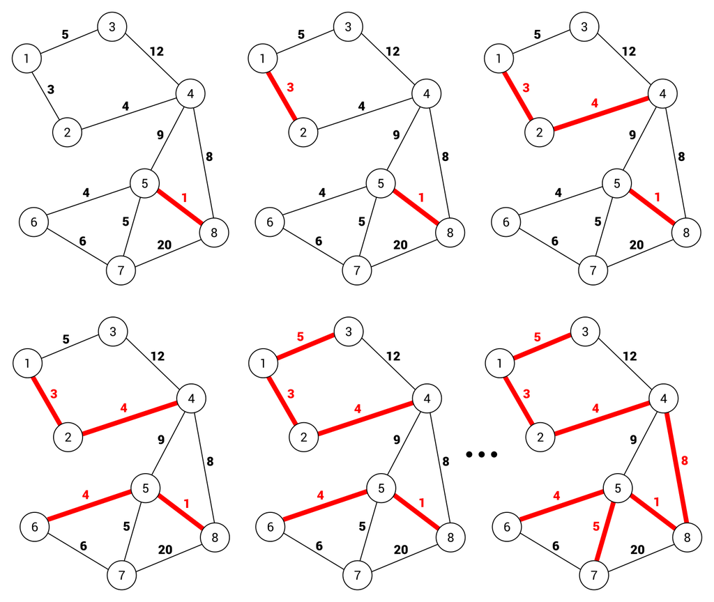

Exemplo do algoritmo de Kruskal

As arestas não precisam estar conectado em um ponto em comum, como ocorre no algoritmo de Prim, são focados em arestas que podem estar em qualquer lugar no grafo mas que sejam seguros e que tenham o menor peso.

### Links

[Visão rápida do que é MST](https://www.youtube.com/watch?v=eHC2tjQPX3A)

[Apresentação que não tive paciência pra ver](https://www.youtube.com/watch?v=tCheLd4H-nM&t=304s)

[Aula do MIT (em inglês)](https://www.youtube.com/watch?v=tKwnms5iRBU)

[Apresentação de MST](http://www.dt.fee.unicamp.br/~ricfow/IA881/arvoreGeradora.pdf)

[MST segundo a USP](https://www.ime.usp.br/~pf/algoritmos_para_grafos/aulas/spanningtrees.html#exchange1)

[Apresentação de MST da USP](https://www.ime.usp.br/~coelho/mac0328-2011/aulas/aula20.pdf)

[Conceitos básicos de grafo](https://www.youtube.com/watch?v=MC0u4f334mI)

[Livro para suporte](http://www2.dcc.ufmg.br/livros/algoritmos/cap7/slides/c/completo1/cap7.pdf)

[Livro para suporte 2](http://www.inf.ufrgs.br/~tsrodrigues/utilidades/cormem.pdf)

Prim

[Diferença de Prim com Kruskal](https://www.quora.com/What-is-the-difference-in-Kruskals-and-Prims-algorithm)